# Data Mining 기말고사

박찬우

2017년 9월 30일

> 문제 1
1. **답: C**  
   IQ와 GPA를 고정하였을 때 기대할 수 있는 salary는 다음과 같습니다.  
   남자: 50 + 20(GPA) + 0.07(IQ) + 0.01(IQ*GPA)*  
   여자*: 85 + 20(GPA) + 0.07(IQ) + 0.01(IQ*GPA) - 10(GPA)  
   따라서 똑같은 조건 하에 GPA가 증가할 수록 남자의 salary 기대값이 더 높아지게 됩니다.
2. **답: $137,100**  
   50 + 20∗4 + 0.07∗110 + 35 + 0.01(4×110) − 10∗(4) = 137.1
3. **답: False**  
   Coefficient의 값이 나타내는 것은 변수에 따른 추정값의 변화량이지, 변수의 유의미성이나 상호효과를 나타내지 않습니다.

> 문제2

mpg 데이터는 기존에 받은 Auto.csv 파일에서 추출

1. **mpg01 변수 추가**

```r
library(dplyr)
Auto = read.csv("Auto.csv", header = T, na.strings = "?")
Auto = na.omit(Auto)
Auto = mutate(Auto, mpg01 = 0)
Auto$mpg01[Auto$mpg > median(Auto$mpg)] = 1
table(Auto$mpg01)
```

```
##
##   0   1
## 196 196
```

2. **행자료 분리, LDA 수행, 오차율 계산**
- 자료 분리

```r
Auto_train = Auto[Auto$year%%2 == 0, ]
Auto_test = Auto[Auto$year%%2 == 1, ]
mpg01_test = Auto_test$mpg01
```

- LDA 수행

```r
library(MASS)
lda_fit = lda(mpg01 ~ cylinders + weight + displacement + horsepower, data = Auto_train)
lda_pred = predict(lda_fit, Auto_test)
```

- 오차율 계산: **약 12.6%**

```r
mean(lda_pred$class != mpg01_test)
```

```
## [1] 0.1263736
```

3. **QDA 수행, 혼동행렬 생성, 오차율 계산**
- QDA 수행

```r
qda_fit = qda(mpg01 ~ cylinders + weight + displacement + horsepower, data = Auto_train)
qda_pred = predict(qda_fit, Auto_test)
```

- 혼동행렬 계산

```r
table(prediction = qda_pred$class, `actual value` = mpg01_test)
```

```
##           actual value
## prediction  0  1
##          0 89 13
##          1 11 69
```

- 오차율 계산: **약 13.2%**

```r
mean(qda_pred$class != mpg01_test)
```

```
## [1] 0.1318681
```

4. **다중 로지스틱 회귀분석 수행, 예측값 비교/오차율 계산**
- 다중 로지스틱 회귀분석

```r
glm_fit = glm(mpg01 ~ cylinders + weight + displacement + horsepower, data = Auto_train,
    family = binomial)
```

- 예측값 비교

```r
glm_probs = predict(glm_fit, Auto_test, type = "response")
glm_pred = rep(0, length(glm_probs))
glm_pred[glm_probs > 0.5] = 1
table(prediction = glm_pred, `actual value` = Auto_test$mpg01)
```

```
##           actual value
## prediction  0  1
##          0 89 11
##          1 11 71
```

- 오차율 계산: **약 12.1%**

```r
mean(glm_pred != mpg01_test)
```

```
## [1] 0.1208791
```

5. **KNN 수행, 조건부 오차율 계산**
- KNN 수행

```r
library(class)
train_x = Auto_train[, c(2, 5, 3, 4)]
train_mpg01 = Auto_train$mpg01
test_x = Auto_test[, c(2, 5, 3, 4)]
```

- 오차율|k=1: **약 15.4%**

```r
set.seed(1)
knn_pred = knn(train_x, test_x, train_mpg01, k = 1)
mean(knn_pred != mpg01_test)
```

```
## [1] 0.1538462
```

- 오차율|k=10: **약 16.5%**

```r
knn_pred = knn(train_x, test_x, train_mpg01, k = 10)
mean(knn_pred != mpg01_test)
```

```
## [1] 0.1648352
```

- 오차율|k=100: **약 14.3%**

```r
knn_pred = knn(train_x, test_x, train_mpg01, k = 100)
mean(knn_pred != mpg01_test)
```

```
## [1] 0.1428571
```

> 문제 3

#### ideo_self 모형을 구축하고, ideo_self = NA 에 대한 예측 시행

#### * 1번부터 900열 까지의 데이터로 모형을 구축

#### * 901열부터 ideo_self = NA에 대한 예측 시행

#### * 모델은 KNN을 사용하여 정치성향 추정

1. 자료 전처리
- 자료 내 NA 항목이 많음
- NA는 진보/보수 입장을 표명하지 않은 무응답 표이므로 나름 의미가 있다고 가정하고, ’9’란 값을 기입하여 의미 부여

```r
library(xlsx)
ideo_data = read.xlsx2("data1.xlsx", 1, startRow = 2, header = T, stringsAsFactors = F)
# 자료 정수화
for (i in 1:ncol(ideo_data)) {
    ideo_data[, i] = as.integer(ideo_data[, i])
}
# k3 변수 [1,2]에서 [0,1]로 수정
ideo_data$k3 = ideo_data$k3 - 1

# NA 대신 '9'라는 factor 추가
ideo_data[is.na(ideo_data)] = 9

# age 변수 제외하고 factor화
for (i in c(1:4, 6:ncol(ideo_data))) {
    ideo_data[, i] = as.factor(ideo_data[, i])
}

# 다음 변수 삭제 [x.(행번호), id, birth(나이 변수와 중복), age(age1이 실제
# 나이)]
ideo_data = ideo_data[, c(-1, -2, -4, -6)]

head(ideo_data, 5)
```

```
##   sex age1 area edu income k2 k3 k4 k6 k7 k8 k10 k12 k13 k14 ideo_self
## 1   1   22    1   2      1  1  0  0  1  0  0   9   1   0   9         5
## 2   1   59    8   4      1  1  1  1  1  0  1   0   0   1   1         7
## 3   1   26    4   2      1  0  1  1  1  0  0   0   0   0   1        10
## 4   2   50    2   4      7  9  1  0  0  9  0   9   9   0   0         3
## 5   1   38    1   4      1  1  1  1  0  0  0   1   1   0   1         6
```

2. 데이터 분할
- 데이터는 총 3종류로 분할 (train/test/validation)
- train set은 1:900열 중 임의로 600개를 추출하여 모델링에 사용
- test set은 나머지 300개로 모델링을 검증하는데 사용 (정답률)
- validation set은 900열 이후 ideo_self 값이 na인 데이터로, 최선을 모델로 실제 값을 추정

```r
set.seed(1234)
train_set = sample(1:900, 600)
ideo_train = na.omit(ideo_data[train_set, ])
ideo_test = na.omit(ideo_data[!1:900 %in% train_set, ])

knn_train = ideo_train[, 1:(ncol(ideo_train) - 1)]
knn_test = ideo_test[, 1:(ncol(ideo_train) - 1)]
real_ideo = ideo_train[, ncol(ideo_train)]
```

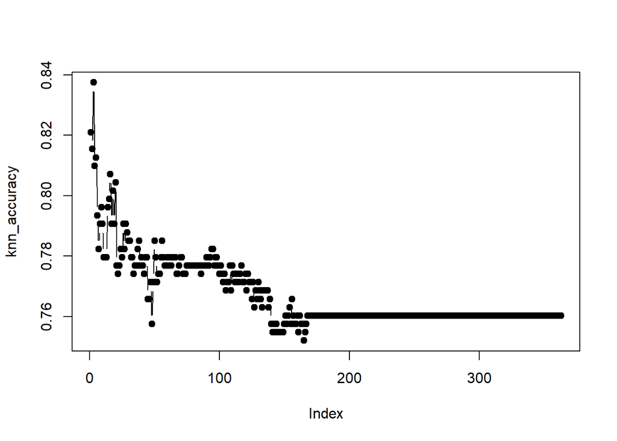

```r
knn_accuracy = NULL
for (i in (1:nrow(knn_test))) {
    test_pred = knn(knn_train, knn_test, real_ideo, k = i)
    knn_accuracy = c(knn_accuracy, sum(test_pred != ideo_test$ideo_self)/length(test_pred))
}
plot(knn_accuracy, type = "b", pch = 19)
```

```r
which(knn_accuracy == max(knn_accuracy))
```

```
## [1] 3
```

```r
knn_accuracy[2]
```

```
## [1] 0.815427
```

```r
target_group = ideo_data[901:nrow(ideo_data), ]
target_group_variables = target_group[, 1:(ncol(target_group) - 1)]

test_pred = knn(knn_train, target_group_variables, real_ideo, k = 2)
```

- 아래와 같은 분포로 총 155명의 정치성향 분석 완료

```r
target_group$ideo_self = test_pred
target_group_profile = target_group[, c(ncol(target_group), 1:5)]
profile_summ = target_group %>% group_by(ideo_self) %>% tally()
profile_summ
```

```
## # A tibble: 11 x 2
##    ideo_self     n
##       <fctr> <int>
##  1         0     2
##  2         1     5
##  3         2     6
##  4         3    20
##  5         4    10
##  6         5    55
##  7         6    17
##  8         7    15
##  9         8    12
## 10         9     4
## 11        10     9
```

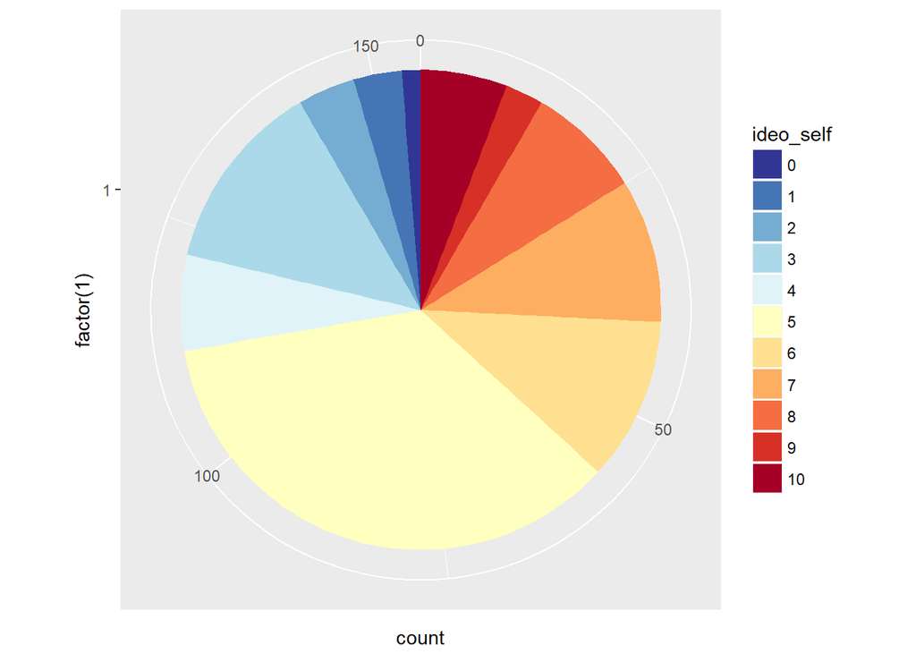

```r
library(ggplot2)
library(RColorBrewer)
ggplot(target_group_profile, aes(x = factor(1), fill = ideo_self)) + geom_bar(width = 1) +
    coord_polar(theta = "y") + scale_fill_manual(values = rev(brewer.pal(11,
    "RdYlBu")))
```

> 문제 4

#### 의원들의 군집을 파악

#### * 투표정보만으로 unsupervised-learning 기반의 clustering 수행

#### * K-means 방식으로 군집분석을 수행 할 예정이며, sum of square 값 기반으로 적정 k값 확정

#### * 정당 정보와 군집분석 간 결과 비교 (단, 상호 연관성이 떨어지더라도, 잘못된 군집이라고 볼 수는 없음)

1. 자료 전처리
- 발의 정보는 legislation 변수에, 정당정보는 politician 변수(추후 비교)에 할당
- 발의 법안 수는 numeric 형태로 변환

```r
politicians = read.xlsx2('data2.xlsx',2)
legislation = read.xlsx2('data2.xlsx',1, stringsAsFactors = F)
for (i in 1:ncol(legislation)){
  legislation[,i] = as.numeric(legislation[,i])
  }
```

2. 군집분석 수행
- 분석 모델은 k-means를 사용하고, k=3으로 우선 결과 확인

```r
legislation_kmeans = kmeans(legislation, centers = 3, iter.max = 10000)
kmeans_cluster = legislation_kmeans$cluster
kmeans_cluster
```

```
##   [1] 2 1 1 2 1 2 1 2 2 1 2 1 2 3 2 3 2 2 2 2 1 1 2 3 2 2 2 1 2 2 2 2 2 1 2
##  [36] 1 2 2 2 1 2 1 1 1 2 1 1 2 2 1 1 1 2 2 2 1 1 1 2 3 1 2 1 1 1 1 2 1 3 1
##  [71] 2 2 2 3 1 2 2 1 1 2 2 1 1 2 2 2 2 1 2 1 2 2 2 3 2 1 1 1 3 2 2 2 2 2 2
## [106] 2 2 1 2 2 1 2 1 2 2 2 2 1 1 2 2 1 1 2 3 1 1 1 2 1 2 1 2 2 2 3 3 1 2 1
## [141] 3
```

- k 값에 따라 sum of squares 변화를 확인하고 최적의 k 선정

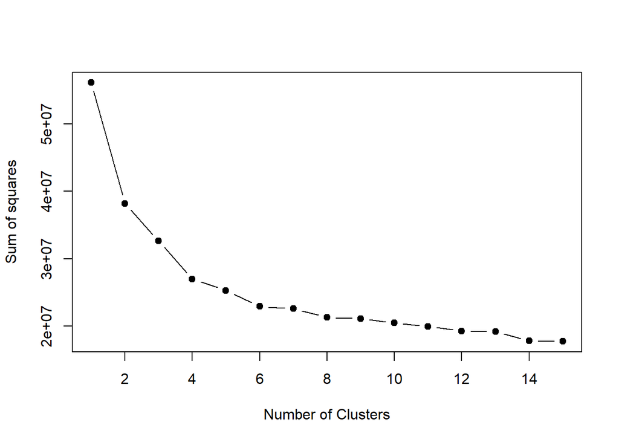

```r
wssplot <- function(data, nc=15, seed=1234){
  wss <- (nrow(data)-1)*sum(apply(data,2,var))
  for (i in 2:nc){
    set.seed(seed)
    wss[i] <- sum(kmeans(data, centers=i)$withinss)}
  plot(1:nc, wss, pch = 19, type="b", xlab="Number of Clusters", ylab="Sum of squares")}
# ref. http://www.dodomira.com/2016/02/20/r%EC%9D%84-%EC%82%AC%EC%9A%A9%ED%95%9C-k-means-%EA%B5%B0%EC%A7%91%EB%B6%84%EC%84%9D-k-means-clustering-in-r/

wssplot(legislation)
```

- k > 6에서 sum of squares가 완만한 곡선을 그리는 모습을 볼 수 있음
- 따라서 **‘k = 6’**으로 군집분석 재수행

```r
legislation_kmeans = kmeans(legislation, centers = 6, iter.max = 10000)
kmeans_cluster = as.factor(legislation_kmeans$cluster)
```

3. 결과 비교
- 4번 클러스터는 100% 자칭 보수를 대변하는 바른정당과 자유한국당으로 이루어져 있음
- 2번 클러스터는 100% 더불어민주당 당원으로 구성
- 3번 클러스터는 100% 국민의당 당원으로 구성
- 법안 발의 성향 기반의 군집 분석과 소속 당과는 어느 정도 연관성이 있고, 따라서 당과 법안 발의 가운데도 연관성을 찾아볼 수 있었음  
  *보수 정당의 경우 그 정도가 심하다고 볼 수 있음*

```r
politicians = cbind(politicians,  'clustered' = kmeans_cluster)

head(politicians)
```

```
##       id        party clustered
## 1  legi1     바른정당         4
## 2  legi2 더불어민주당         2
## 3  legi5 더불어민주당         2
## 4  legi8   자유한국당         4
## 5  legi9 더불어민주당         2
## 6 legi11   자유한국당         4
```

```r
table(politicians[,2:3])
```

```
##               clustered
## party           1  2  3  4  5  6
##   국민의당      0  0 10  0 13  1
##   더불어민주당 12 39  0  0 14  2
##   무소속        1  0  0  0  0  0
##   바른정당      0  0  0  7  0  0
##   자유한국당    0  0  0 41  0  0
##   정의당        0  0  0  0  1  0
```

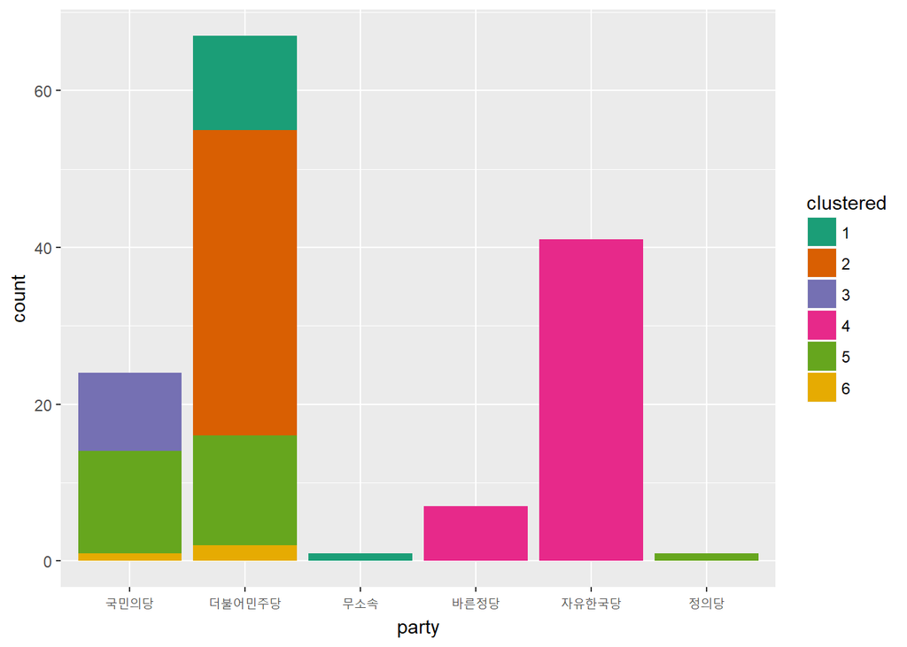

```r
ggplot(politicians[,2:3], aes(x = party, fill = clustered)) + geom_bar() + scale_fill_brewer(palette = 'Dark2')
```